# Project: Communicate Data Findings - Prosper Loan Data

*Muthukumar Palavesam*

- Introduction
- Gathering Data
  - Using `requests` library in python
- Assessment Of Data
- Assessment Summary
- Cleaning the Data
- Storing the cleaned Dataset
- Analyzing and Visualizing
  - Univariate Plots
  - Bivariate Plots
  - Multivariate Plots
- Conclusions
- Limitations
- Resources I used in my analysis

## Introduction

```python
#import the necessary package for this project
import pandas as pd
import numpy as np
import requests
import matplotlib.pyplot as plt
import seaborn as sns
%matplotlib inline
from IPython.display import display, HTML,Markdown,Image
pd.set_option('display.max_columns', None)
pd.set_option('display.max_rows', None)
pd.set_option('display.max_colwidth', 500)
sns.set_style("darkgrid")
```

###### script to print the dataframe borders [Ref Link](https://stackoverflow.com/questions/49888173/python-jupyter-notebook-print-dataframe-borders/51858584)

```python
%%HTML
<style type="text/css">
table.dataframe td, table.dataframe th {
    border: 0.5px  black solid !important;
  color: black !important;
}
</style>
```

## Gathering Data

###### Gathering Data : Using `requests` library in python

```python
url='https://s3.amazonaws.com/udacity-hosted-downloads/ud651/prosperLoanData.csv'
r=requests.get(url)
with open('prosperLoanData.csv',mode='wb') as file:
    file.write(r.content)
```

```python
#Read the CSV file using pandas "read_csv" function
loandata=pd.read_csv('prosperLoanData.csv')
```

## Assessment Of Data

```python
#checking the nature of datas by using the function called "head" and exploring two rows
loandata.head()
```

|  | ListingKey | ListingNumber | ListingCreationDate | CreditGrade | Term | LoanStatus | ClosedDate | BorrowerAPR | BorrowerRate | LenderYield | EstimatedEffectiveYield | EstimatedLoss | EstimatedReturn | ProsperRating (numeric) | ProsperRating (Alpha) | ProsperScore | ListingCategory (numeric) | BorrowerState | Occupation | EmploymentStatus | EmploymentStatusDuration | IsBorrowerHomeowner | CurrentlyInGroup | GroupKey | DateCreditPulled | CreditScoreRangeLower | CreditScoreRangeUpper | FirstRecordedCreditLine | CurrentCreditLines | … |
| --- | --- | --- | --- | --- | --- | --- | --- | --- | --- | --- | --- | --- | --- | --- | --- | --- | --- | --- | --- | --- | --- | --- | --- | --- | --- | --- | --- | --- | --- | --- |
| 0 | 1021339766868145413AB3B | 193129 | 2007-08-26 19:09:29.263000000 | C | 36 | Completed | 2009-08-14 00:00:00 | 0.16516 | 0.1580 | 0.1380 | NaN | NaN | NaN | NaN | NaN | NaN | 0 | CO | Other | Self-employed | 2.0 | True | True | NaN | 2007-08-26 18:41:46.780000000 | 640.0 | 659.0 | 2001-10-11 00:00:00 | 5.0 | … |
| 1 | 10273602499503308B223C1 | 1209647 | 2014-02-27 08:28:07.900000000 | NaN | 36 | Current | NaN | 0.12016 | 0.0920 | 0.0820 | 0.07960 | 0.0249 | 0.05470 | 6.0 | A | 7.0 | 2 | CO | Professional | Employed | 44.0 | False | False | NaN | 2014-02-27 08:28:14 | 680.0 | 699.0 | 1996-03-18 00:00:00 | 14.0 | … |
| 2 | 0EE9337825851032864889A | 81716 | 2007-01-05 15:00:47.090000000 | HR | 36 | Completed | 2009-12-17 00:00:00 | 0.28269 | 0.2750 | 0.2400 | NaN | NaN | NaN | NaN | NaN | NaN | 0 | GA | Other | Not available | NaN | False | True | 783C3371218786870A73D20 | 2007-01-02 14:09:10.060000000 | 480.0 | 499.0 | 2002-07-27 00:00:00 | NaN | … |
| 3 | 0EF5356002482715299901A | 658116 | 2012-10-22 11:02:35.010000000 | NaN | 36 | Current | NaN | 0.12528 | 0.0974 | 0.0874 | 0.08490 | 0.0249 | 0.06000 | 6.0 | A | 9.0 | 16 | GA | Skilled Labor | Employed | 113.0 | True | False | NaN | 2012-10-22 11:02:32 | 800.0 | 819.0 | 1983-02-28 00:00:00 | 5.0 | … |
| 4 | 0F023589499656230C5E3E2 | 909464 | 2013-09-14 18:38:39.097000000 | NaN | 36 | Current | NaN | 0.24614 | 0.2085 | 0.1985 | 0.18316 | 0.0925 | 0.09066 | 3.0 | D | 4.0 | 2 | MN | Executive | Employed | 44.0 | True | False | NaN | 2013-09-14 18:38:44 | 680.0 | 699.0 | 2004-02-20 00:00:00 | 19.0 | … |

```python
#using a "info()" function to get a concise summary of the dataframe
loandata.info()
```

```
<class 'pandas.core.frame.DataFrame'>
RangeIndex: 113937 entries, 0 to 113936
Data columns (total 81 columns):
ListingKey                             113937 non-null object
ListingNumber                          113937 non-null int64
ListingCreationDate                    113937 non-null object
CreditGrade                            28953 non-null object
Term                                   113937 non-null int64
LoanStatus                             113937 non-null object
ClosedDate                             55089 non-null object
BorrowerAPR                            113912 non-null float64
BorrowerRate                           113937 non-null float64
LenderYield                            113937 non-null float64
EstimatedEffectiveYield                84853 non-null float64
EstimatedLoss                          84853 non-null float64
EstimatedReturn                        84853 non-null float64
ProsperRating (numeric)                84853 non-null float64
ProsperRating (Alpha)                  84853 non-null object
ProsperScore                           84853 non-null float64
ListingCategory (numeric)              113937 non-null int64
BorrowerState                          108422 non-null object
Occupation                             110349 non-null object
EmploymentStatus                       111682 non-null object
EmploymentStatusDuration               106312 non-null float64
IsBorrowerHomeowner                    113937 non-null bool
CurrentlyInGroup                       113937 non-null bool
GroupKey                               13341 non-null object
DateCreditPulled                       113937 non-null object
CreditScoreRangeLower                  113346 non-null float64
CreditScoreRangeUpper                  113346 non-null float64
FirstRecordedCreditLine                113240 non-null object
CurrentCreditLines                     106333 non-null float64
OpenCreditLines                        106333 non-null float64
TotalCreditLinespast7years             113240 non-null float64
OpenRevolvingAccounts                  113937 non-null int64
OpenRevolvingMonthlyPayment            113937 non-null float64
InquiriesLast6Months                   113240 non-null float64
TotalInquiries                         112778 non-null float64
CurrentDelinquencies                   113240 non-null float64
AmountDelinquent                       106315 non-null float64
```

[output cut: 31 more lines]

```
LP_CustomerPayments                    113937 non-null float64
LP_CustomerPrincipalPayments           113937 non-null float64
LP_InterestandFees                     113937 non-null float64
LP_ServiceFees                         113937 non-null float64
LP_CollectionFees                      113937 non-null float64
LP_GrossPrincipalLoss                  113937 non-null float64
LP_NetPrincipalLoss                    113937 non-null float64
LP_NonPrincipalRecoverypayments        113937 non-null float64
PercentFunded                          113937 non-null float64
Recommendations                        113937 non-null int64
InvestmentFromFriendsCount             113937 non-null int64
InvestmentFromFriendsAmount            113937 non-null float64
Investors                              113937 non-null int64
dtypes: bool(3), float64(50), int64(11), object(17)
memory usage: 68.1+ MB
```

```python
#Checking the NaN Records in Dataset
null_counts=loandata.isnull().sum()
null_counts[null_counts>0].sort_values(ascending=False)
```

```
GroupKey                               100596
LoanFirstDefaultedCycleNumber           96985
ScorexChangeAtTimeOfListing             95009
ProsperPrincipalOutstanding             91852
ProsperPrincipalBorrowed                91852
ProsperPaymentsOneMonthPlusLate         91852
ProsperPaymentsLessThanOneMonthLate     91852
OnTimeProsperPayments                   91852
TotalProsperPaymentsBilled              91852
TotalProsperLoans                       91852
CreditGrade                             84984
ClosedDate                              58848
EstimatedReturn                         29084
EstimatedEffectiveYield                 29084
EstimatedLoss                           29084
ProsperScore                            29084
ProsperRating (numeric)                 29084
ProsperRating (Alpha)                   29084
DebtToIncomeRatio                        8554
EmploymentStatusDuration                 7625
AmountDelinquent                         7622
BankcardUtilization                      7604
RevolvingCreditBalance                   7604
PublicRecordsLast12Months                7604
OpenCreditLines                          7604
CurrentCreditLines                       7604
TotalTrades                              7544
TradesNeverDelinquent (percentage)       7544
TradesOpenedLast6Months                  7544
AvailableBankcardCredit                  7544
BorrowerState                            5515
Occupation                               3588
EmploymentStatus                         2255
TotalInquiries                           1159
DelinquenciesLast7Years                   990
FirstRecordedCreditLine                   697
TotalCreditLinespast7years                697
InquiriesLast6Months                      697
CurrentDelinquencies                      697
PublicRecordsLast10Years                  697
CreditScoreRangeLower                     591
CreditScoreRangeUpper                     591
BorrowerAPR                                25
dtype: int64
```

```python
#Printing the number of rows and columns of intial dataset
print('The Intial Dataset now have {} number of rows and {} columns'.format(loandata.shape[0],loandata.shape[1]))
```

```
The Intial Dataset now have 113937 number of rows and 81 columns
```

```python
# checking the duplicated data entries
loandata.duplicated().any()
```

```
False
```

```python
loandata.describe()
```

|  | ListingNumber | Term | BorrowerAPR | BorrowerRate | LenderYield | EstimatedEffectiveYield | EstimatedLoss | EstimatedReturn | ProsperRating (numeric) | ProsperScore | ListingCategory (numeric) | EmploymentStatusDuration | CreditScoreRangeLower | CreditScoreRangeUpper | CurrentCreditLines | OpenCreditLines | TotalCreditLinespast7years | OpenRevolvingAccounts | OpenRevolvingMonthlyPayment | InquiriesLast6Months | TotalInquiries | CurrentDelinquencies | AmountDelinquent | DelinquenciesLast7Years | PublicRecordsLast10Years | PublicRecordsLast12Months | RevolvingCreditBalance | BankcardUtilization | AvailableBankcardCredit | … |
| --- | --- | --- | --- | --- | --- | --- | --- | --- | --- | --- | --- | --- | --- | --- | --- | --- | --- | --- | --- | --- | --- | --- | --- | --- | --- | --- | --- | --- | --- | --- |
| count | 1.139370e+05 | 113937.000000 | 113912.000000 | 113937.000000 | 113937.000000 | 84853.000000 | 84853.000000 | 84853.000000 | 84853.000000 | 84853.000000 | 113937.000000 | 106312.000000 | 113346.000000 | 113346.000000 | 106333.000000 | 106333.000000 | 113240.000000 | 113937.00000 | 113937.000000 | 113240.000000 | 112778.000000 | 113240.000000 | 106315.000000 | 112947.000000 | 113240.000000 | 106333.000000 | 1.063330e+05 | 106333.000000 | 106393.000000 | … |
| mean | 6.278857e+05 | 40.830248 | 0.218828 | 0.192764 | 0.182701 | 0.168661 | 0.080306 | 0.096068 | 4.072243 | 5.950067 | 2.774209 | 96.071582 | 685.567731 | 704.567731 | 10.317192 | 9.260164 | 26.754539 | 6.96979 | 398.292161 | 1.435085 | 5.584405 | 0.592052 | 984.507059 | 4.154984 | 0.312646 | 0.015094 | 1.759871e+04 | 0.561309 | 11210.225447 | … |
| std | 3.280762e+05 | 10.436212 | 0.080364 | 0.074818 | 0.074516 | 0.068467 | 0.046764 | 0.030403 | 1.673227 | 2.376501 | 3.996797 | 94.480605 | 66.458275 | 66.458275 | 5.457866 | 5.022644 | 13.637871 | 4.63097 | 447.159711 | 2.437507 | 6.429946 | 1.978707 | 7158.270157 | 10.160216 | 0.727868 | 0.154092 | 3.293640e+04 | 0.317918 | 19818.361309 | … |
| min | 4.000000e+00 | 12.000000 | 0.006530 | 0.000000 | -0.010000 | -0.182700 | 0.004900 | -0.182700 | 1.000000 | 1.000000 | 0.000000 | 0.000000 | 0.000000 | 19.000000 | 0.000000 | 0.000000 | 2.000000 | 0.00000 | 0.000000 | 0.000000 | 0.000000 | 0.000000 | 0.000000 | 0.000000 | 0.000000 | 0.000000 | 0.000000e+00 | 0.000000 | 0.000000 | … |
| 25% | 4.009190e+05 | 36.000000 | 0.156290 | 0.134000 | 0.124200 | 0.115670 | 0.042400 | 0.074080 | 3.000000 | 4.000000 | 1.000000 | 26.000000 | 660.000000 | 679.000000 | 7.000000 | 6.000000 | 17.000000 | 4.00000 | 114.000000 | 0.000000 | 2.000000 | 0.000000 | 0.000000 | 0.000000 | 0.000000 | 0.000000 | 3.121000e+03 | 0.310000 | 880.000000 | … |
| 50% | 6.005540e+05 | 36.000000 | 0.209760 | 0.184000 | 0.173000 | 0.161500 | 0.072400 | 0.091700 | 4.000000 | 6.000000 | 1.000000 | 67.000000 | 680.000000 | 699.000000 | 10.000000 | 9.000000 | 25.000000 | 6.00000 | 271.000000 | 1.000000 | 4.000000 | 0.000000 | 0.000000 | 0.000000 | 0.000000 | 0.000000 | 8.549000e+03 | 0.600000 | 4100.000000 | … |
| 75% | 8.926340e+05 | 36.000000 | 0.283810 | 0.250000 | 0.240000 | 0.224300 | 0.112000 | 0.116600 | 5.000000 | 8.000000 | 3.000000 | 137.000000 | 720.000000 | 739.000000 | 13.000000 | 12.000000 | 35.000000 | 9.00000 | 525.000000 | 2.000000 | 7.000000 | 0.000000 | 0.000000 | 3.000000 | 0.000000 | 0.000000 | 1.952100e+04 | 0.840000 | 13180.000000 | … |
| max | 1.255725e+06 | 60.000000 | 0.512290 | 0.497500 | 0.492500 | 0.319900 | 0.366000 | 0.283700 | 7.000000 | 11.000000 | 20.000000 | 755.000000 | 880.000000 | 899.000000 | 59.000000 | 54.000000 | 136.000000 | 51.00000 | 14985.000000 | 105.000000 | 379.000000 | 83.000000 | 463881.000000 | 99.000000 | 38.000000 | 20.000000 | 1.435667e+06 | 5.950000 | 646285.000000 | … |

## Assessment Summary

- `LoanOriginationDate` is showing as string, so it needs to be converted to DateTime
- `StatedMonthlyIncome` is showing as four decimal, make that into two decimal points
- `BorrowerAPR` has 25 NaN values.Replace those NaN with mean values
- Convert `BorrowerRate,BorrowerAPR` into percentage(multiply by 100) and round of the value into two decimal point
- Create the column `ListingCategory` and Convert into categorical datatype
- Create the column `HomeownerStatus` and Convert into categorical datatype
- `CreditScoreRangeLower` and `CreditScoreRangeUpper` is showing as Float, need to change the datatype into int64
- There are so many missing values and we can consider to remove the unrequired columns
- Rename the columns into meaningful description and reorder it

## Cleaning the Data

```python
#Make a copy of this object’s indices and data using pandas `copy` function
prosper_df=loandata.copy()
```

###### LoanOriginationDate is showing as string, so it needs to be converted to DateTime

```python
#`LoanOriginationDate` is showing as string, so it needs to be converted to DateTime
prosper_df['LoanOriginationDate']=pd.to_datetime(prosper_df['LoanOriginationDate'])
```

###### StatedMonthlyIncome is showing as four decimal, make that into two decimal points

```python
#`StatedMonthlyIncome` is showing as four decimal, make that into two decimal points
prosper_df['StatedMonthlyIncome']= prosper_df['StatedMonthlyIncome'].round(2)
```

###### BorrowerAPR has 25 NaN values.Replace those NaN with mean values

```python
prosper_df['BorrowerAPR'].fillna(prosper_df['BorrowerAPR'].mean(),inplace=True)
```

###### Convert BorrowerRate,BorrowerAPR into percentage(multiply by 100) and round of the value into two decimal point

```python
#Convert BorrowerRate,BorrowerAPR into percentage(multiply by 100)
prosper_df['BorrowerRate']=prosper_df['BorrowerRate']*100
prosper_df['BorrowerAPR']=prosper_df['BorrowerAPR']*100

#round of the value into two decimal point
prosper_df['BorrowerRate']= prosper_df['BorrowerRate'].round(2)
prosper_df['BorrowerAPR'] = prosper_df['BorrowerAPR'].round(2)
```

###### Create the column ListingCategory and Convert into categorical datatype

```python
# Create the column `ListingCategory`
listcategory={0 : 'Not Available',1 : 'Debt Consolidation', 2 : 'Home Improvement', 3 : 'Business', 4 : 'Personal Loan',
              5 : 'Student Use',6 : 'Auto', 7: 'Other', 8 : 'Baby&Adoption', 9 : 'Boat', 10 : 'Cosmetic Procedure',
              11 : 'Engagement Ring', 12 : 'Green Loans',13 : 'Household Expenses', 14 : 'Large Purchases',
              15 : 'Medical/Dental', 16 : 'Motorcycle', 17 : 'RV', 18 : 'Taxes', 19 : 'Vacation', 20 : 'Wedding Loans'}

#Using map function to create the new column `ListingCategory`
prosper_df['ListingCategory']=prosper_df['ListingCategory (numeric)'].map(listcategory)

##Using astype to convert into category
prosper_df['ListingCategory']=prosper_df['ListingCategory'].astype('category')
```

###### Create the column HomeownerStatus and Convert into categorical datatype

```python
#Using map function to create the new column `HomeownerStatus`
homestatus={False:'Renter',True:'HomeOwner'}
prosper_df['HomeownerStatus']=prosper_df['IsBorrowerHomeowner'].map(homestatus)

##Using astype to convert into category
prosper_df['HomeownerStatus']=prosper_df['HomeownerStatus'].astype('category')
```

###### CreditScoreRangeLower and CreditScoreRangeUpper is showing as Float, need to change the datatype into int64

```python
#CreditScoreRangeLower and CreditScoreRangeUpper is shwoing as Float, need to change the datatype into int64
prosper_df['CreditScoreRangeLower'].fillna(0,inplace=True)
prosper_df['CreditScoreRangeUpper'].fillna(0,inplace=True)

prosper_df['CreditScoreRangeLower']=prosper_df['CreditScoreRangeLower'].astype('int64')
prosper_df['CreditScoreRangeUpper']=prosper_df['CreditScoreRangeUpper'].astype('int64')

prosper_df['CreditScoreRangeLower'].replace(0, '', inplace=True)
prosper_df['CreditScoreRangeUpper'].replace(0, '', inplace=True)
```

###### There are so many missing values and we can consider to remove the unrequired columns

```python
#dropping unnecessary columns
prosper_df.drop(columns=['ListingKey','ListingNumber','ListingCreationDate','CreditGrade','ClosedDate','LenderYield',
                         'EstimatedEffectiveYield','EstimatedLoss','EstimatedReturn','CurrentlyInGroup', 'GroupKey',
                         'DateCreditPulled','FirstRecordedCreditLine', 'CurrentCreditLines', 'OpenCreditLines',
                         'TotalCreditLinespast7years','OpenRevolvingAccounts','OpenRevolvingMonthlyPayment',
                         'InquiriesLast6Months', 'TotalInquiries','CurrentDelinquencies', 'AmountDelinquent',
                         'DelinquenciesLast7Years','PublicRecordsLast10Years','PublicRecordsLast12Months',
                         'RevolvingCreditBalance','TotalTrades','TradesNeverDelinquent (percentage)','IsBorrowerHomeowner',
                         'TradesOpenedLast6Months','DebtToIncomeRatio','IncomeVerifiable','LoanKey','TotalProsperLoans',
                         'TotalProsperPaymentsBilled','OnTimeProsperPayments','ProsperPaymentsLessThanOneMonthLate',
                         'ProsperPaymentsOneMonthPlusLate','ProsperPrincipalBorrowed','ProsperPrincipalOutstanding',
                         'ScorexChangeAtTimeOfListing','LoanCurrentDaysDelinquent', 'LoanFirstDefaultedCycleNumber',
                         'LoanMonthsSinceOrigination','LoanNumber', 'MemberKey', 'LP_CustomerPayments',
                         'LP_CustomerPrincipalPayments', 'LP_InterestandFees', 'LP_ServiceFees','LP_CollectionFees',
                         'LP_GrossPrincipalLoss','LP_NetPrincipalLoss','LP_NonPrincipalRecoverypayments', 'PercentFunded',
                         'Recommendations','InvestmentFromFriendsCount', 'InvestmentFromFriendsAmount', 'Investors',
                         'EmploymentStatus','EmploymentStatusDuration','ProsperRating (numeric)','ListingCategory (numeric)']
                       ,inplace = True)
```

###### Rename the columns into meaningful description

```python
#Rename the columns into meaningful description and reorder it
prosper_df.rename(columns={'Term':'loanterm','ProsperRating (Alpha)':'ProsperRating','LoanOriginalAmount':'loanamt(USD)',
                           'LoanOriginationDate':'loandate','MonthlyLoanPayment':'monthly_pmt(USD)',
                           'StatedMonthlyIncome':'Borrower_monthly_income(USD)','CreditScoreRangeLower':'cbscore_lower_limit',
                           'CreditScoreRangeUpper':'cbscore_upper_limit','IncomeRange':'Annual_income_range(USD)',
                          'BorrowerRate':'BorrowerRate(%)','BorrowerAPR':'BorrowerAPR(%)'},inplace=True)
```

###### Reorder the columns

```python
#https://pandas.pydata.org/pandas-docs/stable/reference/api/pandas.DataFrame.reindex.html
column_seq = ['BorrowerState','LoanOriginationQuarter','loandate','LoanStatus','loanamt(USD)','loanterm','monthly_pmt(USD)',
              'BorrowerRate(%)','BorrowerAPR(%)','Annual_income_range(USD)','Borrower_monthly_income(USD)','Occupation',
              'HomeownerStatus','ListingCategory','ProsperRating','ProsperScore','cbscore_lower_limit',
              'cbscore_upper_limit','BankcardUtilization','AvailableBankcardCredit']
prosper_df = prosper_df.reindex(columns=column_seq)
```

```python
#checking the nature of datas by using the function called "head" and exploring two rows
prosper_df.head()
```

|  | BorrowerState | LoanOriginationQuarter | loandate | LoanStatus | loanamt(USD) | loanterm | monthly_pmt(USD) | BorrowerRate(%) | BorrowerAPR(%) | Annual_income_range(USD) | Borrower_monthly_income(USD) | Occupation | HomeownerStatus | ListingCategory | ProsperRating | ProsperScore | cbscore_lower_limit | cbscore_upper_limit | BankcardUtilization | AvailableBankcardCredit |
| --- | --- | --- | --- | --- | --- | --- | --- | --- | --- | --- | --- | --- | --- | --- | --- | --- | --- | --- | --- | --- |
| 0 | CO | Q3 2007 | 2007-09-12 | Completed | 9425 | 36 | 330.43 | 15.80 | 16.52 | $25,000-49,999 | 3083.33 | Other | HomeOwner | Not Available | NaN | NaN | 640 | 659 | 0.00 | 1500.0 |
| 1 | CO | Q1 2014 | 2014-03-03 | Current | 10000 | 36 | 318.93 | 9.20 | 12.02 | $50,000-74,999 | 6125.00 | Professional | Renter | Home Improvement | A | 7.0 | 680 | 699 | 0.21 | 10266.0 |
| 2 | GA | Q1 2007 | 2007-01-17 | Completed | 3001 | 36 | 123.32 | 27.50 | 28.27 | Not displayed | 2083.33 | Other | Renter | Not Available | NaN | NaN | 480 | 499 | NaN | NaN |
| 3 | GA | Q4 2012 | 2012-11-01 | Current | 10000 | 36 | 321.45 | 9.74 | 12.53 | $25,000-49,999 | 2875.00 | Skilled Labor | HomeOwner | Motorcycle | A | 9.0 | 800 | 819 | 0.04 | 30754.0 |
| 4 | MN | Q3 2013 | 2013-09-20 | Current | 15000 | 36 | 563.97 | 20.85 | 24.61 | $100,000+ | 9583.33 | Executive | HomeOwner | Home Improvement | D | 4.0 | 680 | 699 | 0.81 | 695.0 |

## Stroing the cleaned Dataset

```python
#Saving the cleaned data using the function called "to_csv"
prosper_df.to_csv('prosper_cleaned.csv',index=False)
```

## Analyzing and Visualizing

This section is divided into Three Plots:

- Univariate Plots
  - Which year has the highest number of loans booked?
  - Find out the top 10 occupations of borrowers who got the loan from prosper?
  - How many number of loans booked in each states?
  - How many number of loans under each LoanStatus?
  - Income range distribution
- Bivariate Plots
  - Borrower Interest Rate graph over the year
  - Plot of BorrowerAPR vs ProsperRating
  - Plot of BorrowerAPR vs ProsperScore
  - Plot of Homeowners vs Interest Rate
- Multivariate Plots.
  - How borrower interest rate changed over the years for owner and renter
  - BorrowerAPR vs. CreditScoreRangeUpper & ProsperScore

```python
# Loading the cleaned Data and Exploring
prosper_cleaned_df=pd.read_csv('prosper_cleaned.csv')
```

```python
prosper_cleaned_df.head(2)
```

|  | BorrowerState | LoanOriginationQuarter | loandate | LoanStatus | loanamt(USD) | loanterm | monthly_pmt(USD) | BorrowerRate(%) | BorrowerAPR(%) | Annual_income_range(USD) | Borrower_monthly_income(USD) | Occupation | HomeownerStatus | ListingCategory | ProsperRating | ProsperScore | cbscore_lower_limit | cbscore_upper_limit | BankcardUtilization | AvailableBankcardCredit |
| --- | --- | --- | --- | --- | --- | --- | --- | --- | --- | --- | --- | --- | --- | --- | --- | --- | --- | --- | --- | --- |
| 0 | CO | Q3 2007 | 2007-09-12 | Completed | 9425 | 36 | 330.43 | 15.8 | 16.52 | $25,000-49,999 | 3083.33 | Other | HomeOwner | Not Available | NaN | NaN | 640.0 | 659.0 | 0.00 | 1500.0 |
| 1 | CO | Q1 2014 | 2014-03-03 | Current | 10000 | 36 | 318.93 | 9.2 | 12.02 | $50,000-74,999 | 6125.00 | Professional | Renter | Home Improvement | A | 7.0 | 680.0 | 699.0 | 0.21 | 10266.0 |

```python
prosper_cleaned_df.info()
```

```
<class 'pandas.core.frame.DataFrame'>
RangeIndex: 113937 entries, 0 to 113936
Data columns (total 20 columns):
BorrowerState                   108422 non-null object
LoanOriginationQuarter          113937 non-null object
loandate                        113937 non-null object
LoanStatus                      113937 non-null object
loanamt(USD)                    113937 non-null int64
loanterm                        113937 non-null int64
monthly_pmt(USD)                113937 non-null float64
BorrowerRate(%)                 113937 non-null float64
BorrowerAPR(%)                  113937 non-null float64
Annual_income_range(USD)        113937 non-null object
Borrower_monthly_income(USD)    113937 non-null float64
Occupation                      110349 non-null object
HomeownerStatus                 113937 non-null object
ListingCategory                 113937 non-null object
ProsperRating                   84853 non-null object
ProsperScore                    84853 non-null float64
cbscore_lower_limit             113213 non-null float64
cbscore_upper_limit             113346 non-null float64
BankcardUtilization             106333 non-null float64
AvailableBankcardCredit         106393 non-null float64
dtypes: float64(9), int64(2), object(9)
memory usage: 17.4+ MB
```

```python
#`loandate` is showing as string, so it needs to be converted to DateTime
prosper_cleaned_df['loandate']=pd.to_datetime(prosper_cleaned_df['loandate'])

##Using astype to convert into category
prosper_cleaned_df['ListingCategory']=prosper_cleaned_df['ListingCategory'].astype('category')
prosper_cleaned_df['HomeownerStatus']=prosper_cleaned_df['HomeownerStatus'].astype('category')
prosper_cleaned_df['ProsperRating']=prosper_cleaned_df['ProsperRating'].astype('category')
```

### (i) Univariate Plots

###### (a) Which year has the highest number of loans booked?

```
loandate
2005       22
2006     5906
2007    11460
2008    11552
2009     2047
2010     5652
2011    11228
2012    19553
2013    34345
2014    12172
Name: LoanStatus, dtype: int64
```

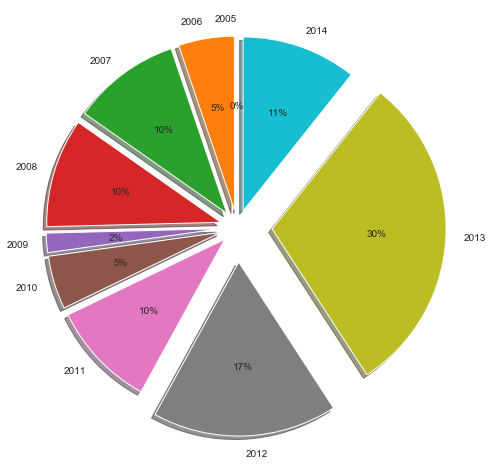

```python
#Plot of ListingYear
print(prosper_cleaned_df.groupby(prosper_cleaned_df['loandate'].dt.year).count()['LoanStatus'].sort_index());

#https://medium.com/@kvnamipara/a-better-visualisation-of-pie-charts-by-matplotlib-935b7667d77f
explode = (0.1, 0.1, 0.1, 0.1, 0.1, 0.1, 0.1, 0.2, 0.2, 0.1)
prosper_cleaned_df.groupby(prosper_cleaned_df['loandate'].dt.year).count()['LoanStatus'].sort_index()\
.plot(kind='pie',explode=explode,figsize=(8,8),shadow = True,startangle = 90,autopct='%1.0f%%');
plt.ylabel("");
```

- By looking into the above plot, most of the loans in the dataset were booked in 2013 followed by 2012. The lowest number of loans were booked in 2005 (22 loans booked) and 2009 (2047 loans booked).

#### (b) Find out the top 10 occupations of borrowers who got the loan from prosper?

```
Other                       28617
Professional                13628
Computer Programmer          4478
Executive                    4311
Teacher                      3759
Administrative Assistant     3688
Analyst                      3602
Sales - Commission           3446
Accountant/CPA               3233
Clerical                     3164
Name: Occupation, dtype: int64
```

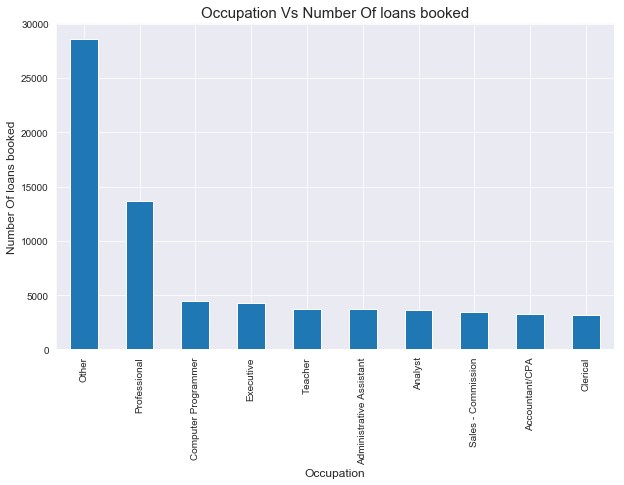

```python
#top 10 occupations of borrowers
print(prosper_cleaned_df['Occupation'].value_counts().nlargest(10));

#plot the bar graph using plot.
prosper_cleaned_df['Occupation'].value_counts().nlargest(10).plot(kind='bar',figsize=(10,6));

#set the labels and titles of the plot.
plt.xlabel('Occupation',fontsize=12)
plt.ylabel('Number Of loans booked',fontsize=12)
plt.title('Occupation Vs Number Of loans booked',fontsize=15);
```

- Most borrowers enter their occupations as "others" or "professional" because they might not want to share this information. The rest of the occupations is showing as least count compare to others.

###### (c) How many number of loans booked in each states?

```
CA    14717
TX     6842
NY     6729
FL     6720
IL     5921
GA     5008
OH     4197
MI     3593
VA     3278
NJ     3097
NC     3084
WA     3048
PA     2972
MD     2821
MO     2615
MN     2318
MA     2242
CO     2210
IN     2078
AZ     1901
WI     1842
OR     1817
TN     1737
AL     1679
CT     1627
SC     1122
NV     1090
KS     1062
KY      983
OK      971
LA      954
UT      877
AR      855
MS      787
NE      674
ID      599
NH      551
NM      472
RI      435
HI      409
WV      391
DC      382
MT      330
DE      300
VT      207
AK      200
SD      189
IA      186
WY      150
ME      101
ND       52
Name: BorrowerState, dtype: int64
```

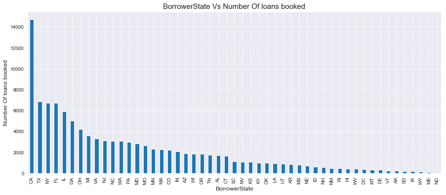

```python
#number of listings in each state
print(prosper_cleaned_df['BorrowerState'].value_counts());

#plot the bar graph using plot.
prosper_cleaned_df['BorrowerState'].value_counts().plot(kind='bar',figsize=(15,6));

#set the labels and titles of the plot.
plt.xlabel('BorrowerState',fontsize=12)
plt.ylabel('Number Of loans booked',fontsize=12)
plt.title('BorrowerState Vs Number Of loans booked',fontsize=15);
```

- Highest number of loans booked in **CA, TX, NY, FL and IL**, which tracks with the rankings of top US states by population and the least in **WY, ME, ND**.

#### (d) How many number of loans under each LoanStatus?

```
Current                   56576
Completed                 38074
Chargedoff                11992
Defaulted                  5018
Past Due (1-15 days)        806
Past Due (31-60 days)       363
Past Due (61-90 days)       313
Past Due (91-120 days)      304
Past Due (16-30 days)       265
FinalPaymentInProgress      205
Past Due (>120 days)         16
Cancelled                     5
Name: LoanStatus, dtype: int64
```

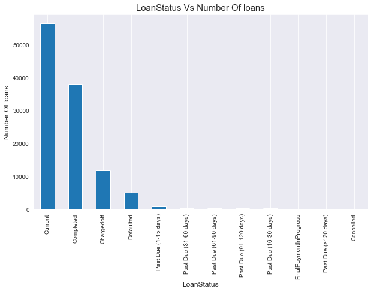

```python
#number of listings under each LoanStatus available
print(prosper_cleaned_df['LoanStatus'].value_counts());

#plot the bar graph using plot.
prosper_cleaned_df['LoanStatus'].value_counts().plot(kind='bar',figsize=(10,6));

#set the labels and titles of the plot.
plt.xlabel('LoanStatus',fontsize=12)
plt.ylabel('Number Of loans',fontsize=12)
plt.title('LoanStatus Vs Number Of loans',fontsize=15);
```

- The number of loans in each LoanStatus type are analyzed . From above bar chart the **Current status** has got the highest number of counts followed by Completed and Chargedoff. Other status include **past dues** and **cancelled** status counts are very less compare to others.

#### (e) Income range distribution

```
$25,000-49,999    32192
$50,000-74,999    31050
$100,000+         17337
$75,000-99,999    16916
Not displayed      7741
$1-24,999          7274
Not employed        806
$0                  621
Name: Annual_income_range(USD), dtype: int64
```

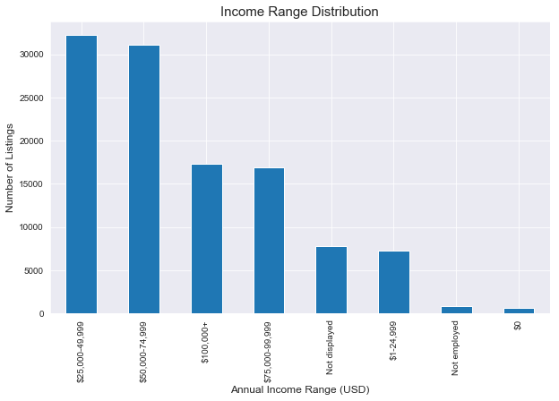

```python
# Income rate distribution of listings
print(prosper_cleaned_df['Annual_income_range(USD)'].value_counts());

#plot the bar graph using plot.
prosper_cleaned_df['Annual_income_range(USD)'].value_counts().plot(kind='bar',figsize=(10,6));

#set the labels and titles of the plot.
plt.xlabel('Annual Income Range (USD)',fontsize=12)
plt.ylabel('Number of Listings',fontsize=12)
plt.title('Income Range Distribution',fontsize=15);
```

-The above plot clearly shows that the majority of borrowers who borrowed loan from prosper **make less than $75000 annual income**.The plot says that **most listings fall under 50000 dollars, followed by 50000-74999 dollars and so on**.

### (ii) Bivariate Plots

```python
prosper_cleaned_df.info()
```

```
<class 'pandas.core.frame.DataFrame'>
RangeIndex: 113937 entries, 0 to 113936
Data columns (total 20 columns):
BorrowerState                   108422 non-null object
LoanOriginationQuarter          113937 non-null object
loandate                        113937 non-null datetime64[ns]
LoanStatus                      113937 non-null object
loanamt(USD)                    113937 non-null int64
loanterm                        113937 non-null int64
monthly_pmt(USD)                113937 non-null float64
BorrowerRate(%)                 113937 non-null float64
BorrowerAPR(%)                  113937 non-null float64
Annual_income_range(USD)        113937 non-null object
Borrower_monthly_income(USD)    113937 non-null float64
Occupation                      110349 non-null object
HomeownerStatus                 113937 non-null category
ListingCategory                 113937 non-null category
ProsperRating                   84853 non-null category
ProsperScore                    84853 non-null float64
cbscore_lower_limit             113213 non-null float64
cbscore_upper_limit             113346 non-null float64
BankcardUtilization             106333 non-null float64
AvailableBankcardCredit         106393 non-null float64
dtypes: category(3), datetime64[ns](1), float64(9), int64(2), object(5)
memory usage: 15.1+ MB
```

#### (a) Borrower Interest Rate graph over the year

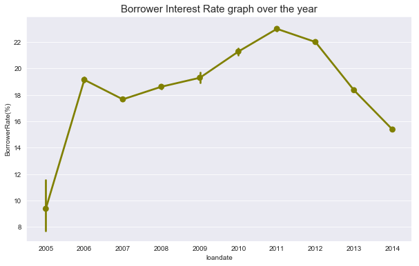

```python
## plots the pointplot for year vs BorrowerRate
fig, ax = plt.subplots(figsize=(10,6))
sns.pointplot(prosper_cleaned_df['loandate'].dt.year,prosper_cleaned_df['BorrowerRate(%)'],color='olive',ax=ax);

#set the labels and titles of the plot.
plt.title('Borrower Interest Rate graph over the year',fontsize=15);
```

- From the above plot,
  - Borrowers interest rate increased from 2005-2006
  - Decreased from 2006-2007
  - After 2007 interest rate constantly shoot up for few years, then reached its peak in 2011 which then started decreasing constantly.

#### (b) Plot of BorrowerAPR vs ProsperRating

| ProsperRating | BorrowerAPR(%) |
| --- | --- |
| HR | 35.8 |
| E | 33.22 |
| D | 28.49 |
| C | 22.36 |
| B | 18.17 |
| A | 13.8 |
| AA | 9 |

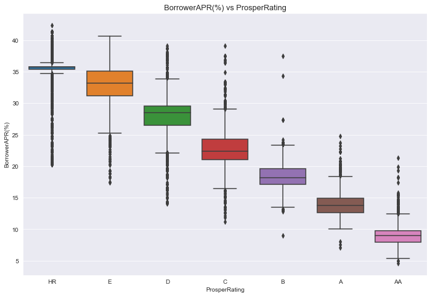

```python
#Displaying the median APR for Prosper Rating
median_df=prosper_cleaned_df.groupby('ProsperRating').median()['BorrowerAPR(%)'].sort_values(ascending=False)
display(median_df.reset_index().style.hide_index())

#boxplot between ProsperRating and APR
prosper_order=['HR','E','D','C','B','A','AA']
fig, ax = plt.subplots(figsize=(12,8))
sns.boxplot(prosper_cleaned_df['ProsperRating'],prosper_cleaned_df['BorrowerAPR(%)'],ax=ax,order=prosper_order);

#set the labels and titles of the plot.
plt.title('BorrowerAPR(%) vs ProsperRating',fontsize=13);
```

- The above boxplots shows the relationship between borrower’s Prosper rating and their assigned Annual Percentage Rate (APR). The APR for the borrower reduces drastically from a ‘High Risk (HR)’ to an ‘AA’ rating. if you see the results, it goes from a median APR of 35.8% for High Risk all the way to a median value of 9% for ‘AA’.

#### (c) Plot of BorrowerAPR vs ProsperScore

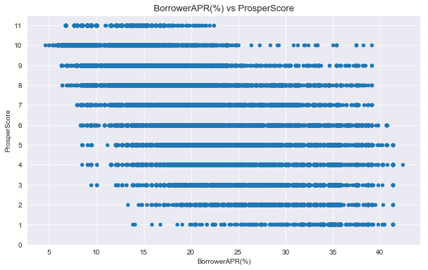

```python
## scatter plot for comparing ProsperScore and BorrowerAPR.
prosper_cleaned_df.plot(kind='scatter',x='BorrowerAPR(%)',y='ProsperScore',figsize=(10,6),yticks= np.arange(0,12,1));

#set the labels and titles of the plot.
plt.title('BorrowerAPR(%) vs ProsperScore',fontsize=13);
```

- The scatter plot above shows that there is a negative relationship between BorrowerAPR and ProsperScore. Because **higher prosperscore is showing as lower APR**. This make sense because the borrower with higher rating tend to be more reliable and therefore given lower BorrowerAPR

#### (d) Plot of Homeowners vs Interest Rate

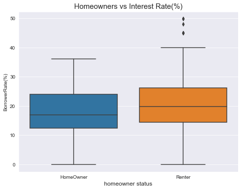

```python
#boxplot between Homeowners and Interest Rate
fig, ax = plt.subplots(figsize=(8,6))
sns.boxplot(prosper_cleaned_df['HomeownerStatus'],prosper_cleaned_df['BorrowerRate(%)'],ax=ax);

#set the labels and titles of the plot.
plt.xlabel('homeowner status',fontsize=12)
plt.title('Homeowners vs Interest Rate(%)',fontsize=15);
```

- The above boxplot clearly shows that the **homeowner customer getting lower interest rate**. This makes sense because If someone has a house,might be more confident that the customers will have conditions to pay back.

### (iii) Multivariate Plots

#### (a) How borrower interest rate changed over the years for owner and renter

| loan_booked_year | renter_median_Rate(%) | homeowner_median_Rate(%) |
| --- | --- | --- |
| 2005 | 8.5 | nan |
| 2006 | 20 | 16.05 |
| 2007 | 18.5 | 15.2 |
| 2008 | 17.7 | 15.15 |
| 2009 | 20.1 | 15.5 |
| 2010 | 26 | 18.8 |
| 2011 | 25.99 | 25.11 |
| 2012 | 22.87 | 21.99 |
| 2013 | 19.14 | 16.6 |
| 2014 | 15.85 | 14 |

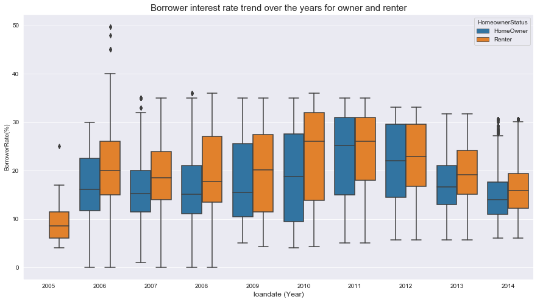

```python
#Renter and owner borrower rate Median value trends over the years
df1=prosper_cleaned_df.query('HomeownerStatus=="Renter"')\
.groupby(prosper_cleaned_df['loandate'].dt.year).median()['BorrowerRate(%)'].reset_index()
df1.rename(columns={'loandate':'loan_booked_year','BorrowerRate(%)':'renter_median_Rate(%)'},inplace=True)

df2=prosper_cleaned_df.query('HomeownerStatus=="HomeOwner"')\
.groupby(prosper_cleaned_df['loandate'].dt.year).median()['BorrowerRate(%)'].round(2).reset_index()
df2.rename(columns={'loandate':'loan_booked_year','BorrowerRate(%)':'homeowner_median_Rate(%)'},inplace=True)

df3=pd.merge(df1, df2, how='outer', on='loan_booked_year')
df3.to_csv('median_rate.csv',index=False)
display(df3.style.hide_index())

#relationships among three variables: borrower  rate, time, and whether the borrower is a homeowner or not
fig, ax = plt.subplots(figsize=(15,8))
sns.boxplot(prosper_cleaned_df['loandate'].dt.year,prosper_cleaned_df['BorrowerRate(%)'],\
            ax=ax,hue=prosper_cleaned_df['HomeownerStatus']);

#set the labels and titles of the plot.
plt.xlabel('loandate (Year)',fontsize=12)
plt.title('Borrower interest rate trend over the years for owner and renter',fontsize=15);
```

- In this plot I studied the relationships among three variables (borrower rate, time, and whether the borrower is a homeowner or not). The above boxplot clearly shows that the **homeowner customer getting lower interest rate in general throughout the years**. This makes sense because If someone has a house,might be more confident that the customers will have conditions to pay back.

#### (b) BorrowerAPR vs. CreditScoreRangeUpper & ProsperScore

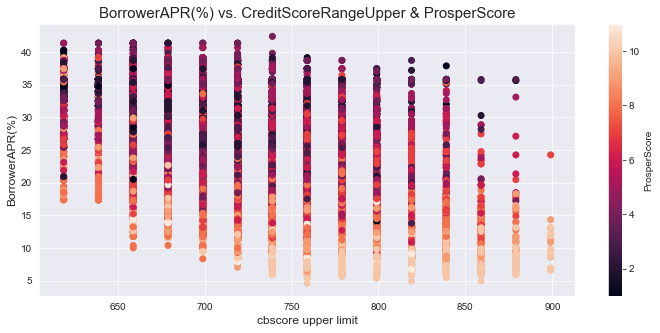

```python
plt.figure(figsize = [12,5])
plt.scatter(data = prosper_cleaned_df, x = 'cbscore_upper_limit', y = 'BorrowerAPR(%)', c = 'ProsperScore');
plt.colorbar(label = 'ProsperScore');

#set the labels and titles of the plot.
plt.xlabel('cbscore upper limit',fontsize=12)
plt.ylabel('BorrowerAPR(%)',fontsize=12)
plt.title('BorrowerAPR(%) vs. CreditScoreRangeUpper & ProsperScore',fontsize=15);
```

- We can see that the **cbscore upper limit increase as BorrowerAPR decrease** in the plots. By adding `ProsperScore` to color encodings, **BorrowerAPR decreases as ProsperScore increases**. This proves the point that **cbscore upper limit and ProsperScore negatively correlated to BorrowerAPR**.

## Conclusions

- Most of the loans in the dataset were booked in 2013 followed by 2012. The lowest number of loans were booked in 2005 (22 loans booked) and 2009 (2047 loans booked)
- Most borrowers enter their occupations as "others" or "professional" because they might not want to share this information.
- Highest number of loans booked in CA, TX, NY, FL and IL and the least in WY, ME, ND.
- The majority of borrowers who borrowed loan from prosper make less than 75000 dollars annual income
- Borrowers interest rate increased from 2005-2006,Decreased from 2006-2007.After 2007 interest rate constantly shoot up for few years, then reached its peak in 2011 which then started decreasing constantly.
- The APR for the borrower reduces drastically from a ‘High Risk (HR)’ to an ‘AA’ rating.
- Higher prosperscore had a lower APR. This make sense because the borrower with higher rating tend to be more reliable and therefore given lower BorrowerAPR
- Homeowner customer getting lower interest rate. This makes sense because If someone has a house,might be more confident that the customers will have conditions to pay back.
- BorrowerAPR decreases as ProsperScore increases. This proves the point that cbscore upper limit and ProsperScore negatively correlated to BorrowerAPR.

## Limitations

- There are so many null values present in the original dataset. Which I didn't consider a lot
- I didn't consider all the variables for my analysis.Only consider 15 to 20 variables.
- I also dropped so many missing values. This also will play huge role and impact on my overall analysis.
- I didn't perform any hypothesis testing

## Resources I used in my analysis

- https://matplotlib.org/users/pyplot_tutorial.html
- https://stackoverflow.com/questions/26868304/how-to-get-rid-of-grid-lines-when-plotting-with-seaborn-pandas-with-secondary
- https://www.youtube.com/watch?v=yuNbn9cczjA
- https://www.geeksforgeeks.org/python-pandas-dataframe-round/
- https://seaborn.pydata.org/generated/seaborn.boxplot.html
- https://seaborn.pydata.org/examples/grouped_boxplot.html
- https://stackoverflow.com/questions/35465557/how-to-apply-color-in-markdown
- https://matplotlib.org/2.0.0/examples/color/named_colors.html
- https://stackoverflow.com/questions/47022070/display-all-dataframe-columns-in-a-jupyter-python-notebook
- https://stackoverflow.com/questions/49888173/python-jupyter-notebook-print-dataframe-borders/51858584